# Mid-term project

Author

Pramod Hegde & Sandesh Shresta

# 1 Mid-term project GitHub repository URL:

Paste here the URL of the GitHub project (after going through the instruction steps) https://github.com/Promode45/midproject_group4

# 2 Introduction

Gross Primary Production(GPP) and soil respiration make the highest carbon fluxes from the terrestrial ecosystem to the atmosphere (Bond-Lamberty and Thomson, 2010). Due to the magnitude of the CO2 flux from soils to atmosphere and the huge reserve of potential C in soils, any increases in soil respiration due to man-made or environmental changes may increase atmospheric CO2 levels and exacerbate global warming. Soil respiration consists mainly of respiration from roots, mycorrhizal fungi and microbes. Microbial respiration of soil C is the highest of the three (Wang and Fang, 2009).

Human activities have been significantly modifying biogeochemical cycles in many ways. Management practices like tillage and fertilization are one of the key factors contributing to increasing CO2 efflux from soils. Nitrogen is the most important component for plant growth, is often limiting in ecosystems, and could affect soil respiration by altering microbial biomass, their activity and root growth (Ding et al.,2010). Studies have found a sharp increase in CO2 efflux following tillage, mainly due to broken soil clods and aggregates which act as “gas tankers” (Fielder et al., 2015; Morell et al., 2012). Although, sharp increases of CO2 efflux are seen following tillage, the extent of the increase depends on cultivation type, Soil Organic Carbon (SOC), soil texture and structure.

Soil temperature and soil water content are considered the main environmental controls of soil respiration, as these can affect both microbial and root growth. The indirect effects of these factors, nutrient availability and plant productivity can also affect CO2 efflux from soils. Rainfall events can result in changes in both soil temperature and water content, and has been part of numerous studies (Shi et al., 2011; Muhr and Borken, 2009; Morell et al., 2012). But there are very few studies, where the combined effects of management practices, soil temperature and soil moisture have been studied.

In this experiment, we try to see the effects of common land management practices on soil respiration across different days following precipitation.

# 3 Hypothesis and objectives

We hypothesize that, soil respiration increases with fertilization and tillage. Additionally, we believe that plots under these treatments will have a higher respiration following precipation as compared to the control plots.

The objectives of this study are (a) to assess the effects of treatments fertilization, tillage or their combined effects on soil CO2 flux over six different days, (b) to assess the effects of precipitation on soil CO2 flux.

# 4 Material and Methods

## 4.1 Site description

The study was conducted at the Whitehall forest in the Piedmont regions Clarke and Ocoonee county in Athens, Georgia, USA. The area has a humid subtropical climate with a mean annual precipitation of 1267.3 mm, and average January and July temperatures of 6.3 degree C and 26.3 degree C respectively. Average elevation is approximately 200m above mean sea level.

## 4.3 Study design

The study consists of a set of five completely randomized blocks (within-site spatial replicates), each with five, 5x5m plots receiving either long-term nutrient addition, a physical disturbance, nutrient addition combined with disturbance, short-term nutrient addition or no treatments. The treatments were done just once at the beginning of summer every year (mid June). The randomization of the study site was carried out using a R code given on the project website (https://nutnet.org/sites/default/files/2019-07/create-site-maps-dragnet-03-July-2019.R).

## 4.4 Statistical analysis

Soil respiration for different treatments were analyzed using a repeated measured mixed-effect ANOVA. Model explanatory variables included treatment (as categorical variable), days after rain (repeated measure) and their interaction as fixed effects. Plot which was nested inside blocks was modeled as the random effect. Different error correlation structures like ARMA(1), exponential, Gaussian,linear etc were applied and the one with the lowest Akaike Information Criterion (AIC) was selected for further analysis. The repeated measures were of unequal time intervals, and hence the choice of correlation structures were limited. Soil moisture and temperature were also measured, since these two factors are known to have an effect on how microbes respire carbon dioxide. The two factors were considered as covariates, and hence accordingly an ANCOVA was also conducted. The assumptions of ANCOVA are as follows -

1. Linear relationships - the effect of the categorical variable on the outcome varies linearly with the outcome.
2. Homogeneity of slopes - The relationship between the dependent and independent variable should be consistent across all the treatment levels. Slopes of regression lines (representing the effect of covariates) should be parallel for each group.
3. Uncorrelated covariates - The covariates must not be correlated to the error term.

We ran the ANCOVA model, and checked for one of the assumptions, which were not satisfied. Hence, we went ahead with the mixed-effects ANOVA. We used an alpha level of 0.05. We used the linear mixed effect mdoel (lme) from the package nlme (Pinheiro and Bates, 2000). The linearity assumptions were checked using the QQ-plot, and a point graph to check for normality, outliers and homoscedascity. **The assumption of outliers was not met, since we found two residuals that were off the limit of 3 standard deviations. But, the raw data points were checked and it did not seem out of place, and hence we decided to not remove them from our analysis.** Apart from this, all assumptions were satisfied without any problems.

# 5 Results

## 5.1 Loading Packages

In this chunk, packages will be loaded that will be used in the process of the analysis.

```r
#|message: False
#|warning: False
library(tidyverse)
library(janitor)
library(stringr)
library(ggpubr)
library(broom)
library(rstatix)
library(lme4)
library(nlme)
library(emmeans)
library(multcomp)
```

## 5.2 importing data

We will import data in the following chunk

```
      Plot     Treatment         R1..01.29.24.    R2..01.30.24.
 Min.   : 1   Length:25          Min.   :0.4041   Min.   :0.3324
 1st Qu.: 7   Class :character   1st Qu.:0.6613   1st Qu.:0.6341
 Median :13   Mode  :character   Median :0.8902   Median :0.7784
 Mean   :13                      Mean   :0.9132   Mean   :0.7939
 3rd Qu.:19                      3rd Qu.:1.0568   3rd Qu.:0.9136
 Max.   :25                      Max.   :1.8122   Max.   :1.3065
 R3..01.31.24.    R4..02.05.24.    R5..02.06.24.    R6..02.07.24.
 Min.   :0.4370   Min.   :0.3206   Min.   :0.3255   Min.   :0.2951
 1st Qu.:0.6154   1st Qu.:0.5355   1st Qu.:0.6058   1st Qu.:0.4901
 Median :0.8127   Median :0.6756   Median :0.7171   Median :0.6940
 Mean   :0.8028   Mean   :0.7027   Mean   :0.7570   Mean   :0.7048
 3rd Qu.:0.9738   3rd Qu.:0.7934   3rd Qu.:0.9276   3rd Qu.:0.8595
 Max.   :1.2936   Max.   :1.2123   Max.   :1.1480   Max.   :1.1814
      swc1             swc2             swc3             swc4
 Min.   :0.1605   Min.   :0.2199   Min.   :0.2162   Min.   :0.1765
 1st Qu.:0.2741   1st Qu.:0.2838   1st Qu.:0.2800   1st Qu.:0.3159
 Median :0.3193   Median :0.3173   Median :0.3224   Median :0.3386
 Mean   :0.3083   Mean   :0.3107   Mean   :0.3101   Mean   :0.3364
 3rd Qu.:0.3547   3rd Qu.:0.3557   3rd Qu.:0.3487   3rd Qu.:0.3670
 Max.   :0.3918   Max.   :0.3781   Max.   :0.3725   Max.   :0.4343
      swc5             swc6             st1              st2
 Min.   :0.2197   Min.   :0.1823   Min.   : 8.869   Min.   :16.00
 1st Qu.:0.2859   1st Qu.:0.2498   1st Qu.:16.362   1st Qu.:17.51
 Median :0.3431   Median :0.2948   Median :17.099   Median :17.96
 Mean   :0.3234   Mean   :0.2921   Mean   :16.683   Mean   :18.04
 3rd Qu.:0.3607   3rd Qu.:0.3492   3rd Qu.:17.510   3rd Qu.:18.52
 Max.   :0.3943   Max.   :0.3647   Max.   :18.922   Max.   :20.02
      st3             st4             st5             st6
 Min.   :14.38   Min.   :11.90   Min.   :16.80   Min.   :13.74
 1st Qu.:16.83   1st Qu.:13.79   1st Qu.:18.23   1st Qu.:16.62
 Median :17.54   Median :14.90   Median :19.05   Median :17.86
 Mean   :17.86   Mean   :14.50   Mean   :18.89   Mean   :17.24
 3rd Qu.:18.98   3rd Qu.:15.40   3rd Qu.:19.63   3rd Qu.:18.46
 Max.   :20.42   Max.   :16.45   Max.   :20.48   Max.   :19.20
```

## 5.3 Data wrangling

In this chunk, we will manipulate and prepare the data for further analysis, including cleaning column header name, creating a column for rep(block), converting variables to appropriate data types and reshaping the data into a more suitable format for analysis.

```r
data_w <- data[-26,] %>%
  clean_names() %>%
  mutate(treatment = factor(treatment)) %>%

  mutate(
    rep = case_when
    (plot == c(1:5) ~ "1",
    plot == c(6:10) ~ "2",
      plot == c(11:15) ~ "3",
      plot == c(16:20) ~ "4",
      plot == c(21:25) ~ "5"
     )
  ) %>%
  mutate(rep = factor(rep)) %>%
  pivot_longer(cols =r1_01_29_24:r6_02_07_24,
               values_to = "respiration",
               names_to = "x1")   %>%
   mutate(x1 = gsub("resp", "", x1)) %>%
 mutate(date1 = str_extract(x1, "\\d{2}_\\d{2}_\\d{2}")
  ) %>%
  mutate(date = as.Date(date1, "%m_%d_%y")) %>%
  mutate(dar = case_when(
    date == "2024-01-29" ~ "01",
    date == "2024-01-30" ~ "02",
    date == "2024-01-31" ~ "03",
    date == "2024-02-05" ~ "08",
    date == "2024-02-06" ~ "09",
    date == "2024-02-07" ~ "10"
  )) %>%
  mutate(fdar = factor(dar)) %>%
  mutate(dar = as.numeric(dar)) %>%
  dplyr::select(c(-x1,-date1)) %>%
  mutate(plot=factor(plot))


summary(data_w)
```

```
      plot                 treatment       swc1             swc2
 1      :  6   Control          :30   Min.   :0.1605   Min.   :0.2199
 2      :  6   Disturbance      :30   1st Qu.:0.2741   1st Qu.:0.2838
 3      :  6   NPK              :30   Median :0.3193   Median :0.3173
 4      :  6   NPK + disturbance:30   Mean   :0.3083   Mean   :0.3107
 5      :  6   NPK Cessation    :30   3rd Qu.:0.3547   3rd Qu.:0.3557
 6      :  6                          Max.   :0.3918   Max.   :0.3781
 (Other):114
      swc3             swc4             swc5             swc6
 Min.   :0.2162   Min.   :0.1765   Min.   :0.2197   Min.   :0.1823
 1st Qu.:0.2800   1st Qu.:0.3159   1st Qu.:0.2859   1st Qu.:0.2498
 Median :0.3224   Median :0.3386   Median :0.3431   Median :0.2948
 Mean   :0.3101   Mean   :0.3364   Mean   :0.3234   Mean   :0.2921
 3rd Qu.:0.3487   3rd Qu.:0.3670   3rd Qu.:0.3607   3rd Qu.:0.3492
 Max.   :0.3725   Max.   :0.4343   Max.   :0.3943   Max.   :0.3647

      st1              st2             st3             st4
 Min.   : 8.869   Min.   :16.00   Min.   :14.38   Min.   :11.90
 1st Qu.:16.362   1st Qu.:17.51   1st Qu.:16.83   1st Qu.:13.79
 Median :17.099   Median :17.96   Median :17.54   Median :14.90
 Mean   :16.683   Mean   :18.04   Mean   :17.86   Mean   :14.50
 3rd Qu.:17.510   3rd Qu.:18.52   3rd Qu.:18.98   3rd Qu.:15.40
 Max.   :18.922   Max.   :20.02   Max.   :20.42   Max.   :16.45

      st5             st6        rep     respiration          date
 Min.   :16.80   Min.   :13.74   1:30   Min.   :0.2951   Min.   :2024-01-29
 1st Qu.:18.23   1st Qu.:16.62   2:30   1st Qu.:0.5894   1st Qu.:2024-01-30
 Median :19.05   Median :17.86   3:30   Median :0.7534   Median :2024-02-02
 Mean   :18.89   Mean   :17.24   4:30   Mean   :0.7791   Mean   :2024-02-02
 3rd Qu.:19.63   3rd Qu.:18.46   5:30   3rd Qu.:0.9294   3rd Qu.:2024-02-06
 Max.   :20.48   Max.   :19.20          Max.   :1.8122   Max.   :2024-02-07

      dar       fdar
 Min.   : 1.0   01:25
 1st Qu.: 2.0   02:25
 Median : 5.5   03:25
 Mean   : 5.5   08:25
 3rd Qu.: 9.0   09:25
 Max.   :10.0   10:25
```

Some references for the data, swc stands for Soil Water Content, st stands for Soil temperature, 1-6 being the different days of measurement, dar being Days After Rain, date is the date of measurement.

## 5.4 EDA - Exploratory Data Analysis

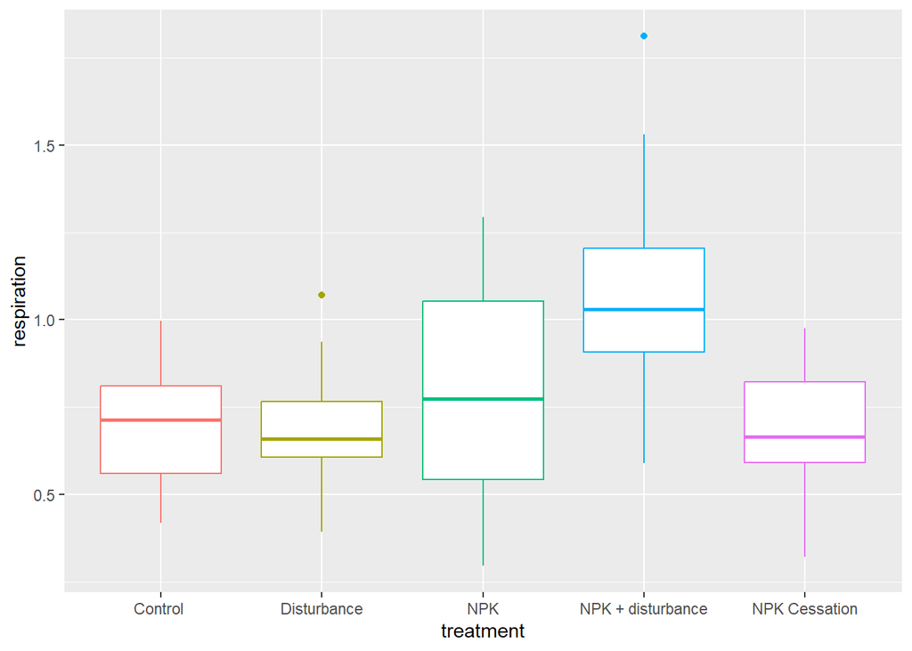

```r
data_w %>%
  group_by(fdar) %>%
  ggplot(aes(treatment,respiration,
             color = treatment
             ))+
  theme(legend.position = "none")+
  geom_boxplot()
```

From the above graph, we can make an initial analysis saying that the plots with NPK treatments have in general a higher respiration value, especially the combined effects of NPK and disturbance,

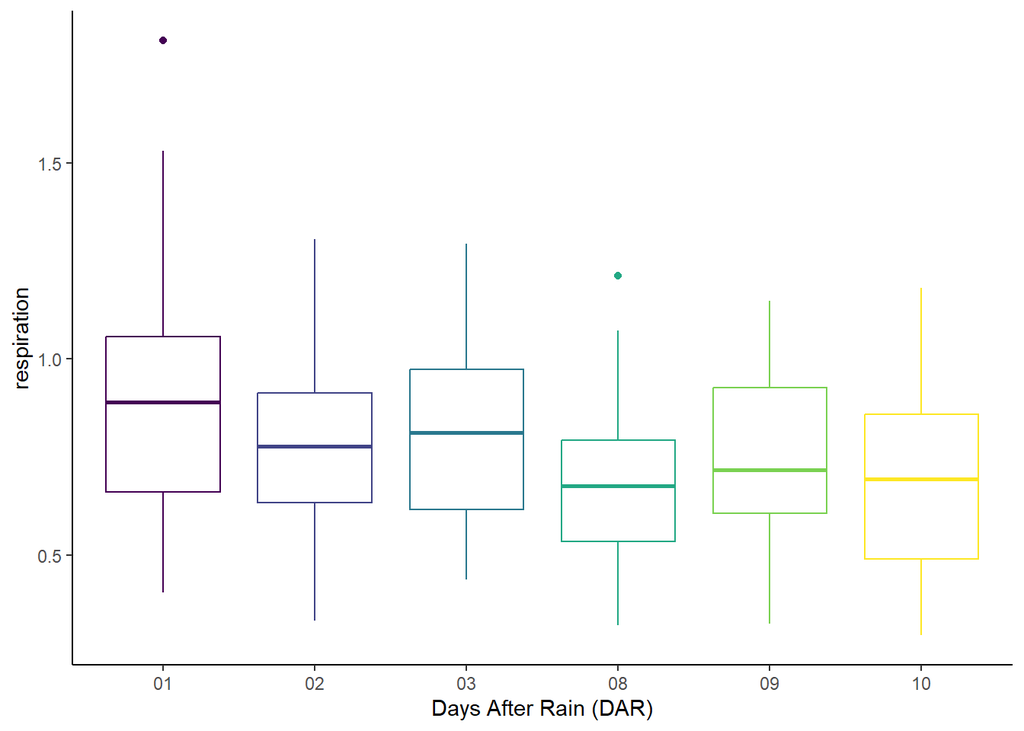

```r
data_w %>%
  group_by(treatment) %>%
  ggplot(aes(fdar, respiration,
             color = fdar))+
  labs(x = "Days After Rain (DAR)")+
  geom_boxplot()+
  theme_classic()+
  theme(legend.position = "none")+
  scale_color_viridis_d()
```

Although not too different, we could still say that respiration values the day right after a rain were higher than the other days. This is also part of our hypothesis.

Here, we will inspect the distribution of respiration across different level of days after rain (dar), segmented by treatment, which can provide insights into potential relationships and patterns in the data.

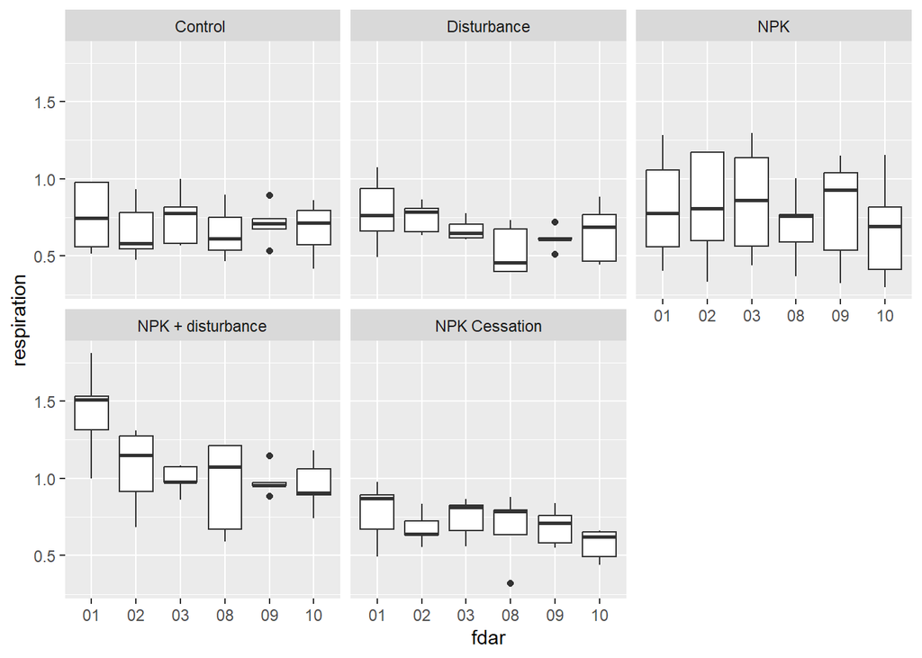

```r
data_w %>%
  ggplot(aes(fdar,respiration))+
  geom_boxplot()+
 facet_wrap(~treatment)
```

## 5.5 Ancova

In the chunk below, we will reshape data and visualize the data to check the linearity of the covariates.

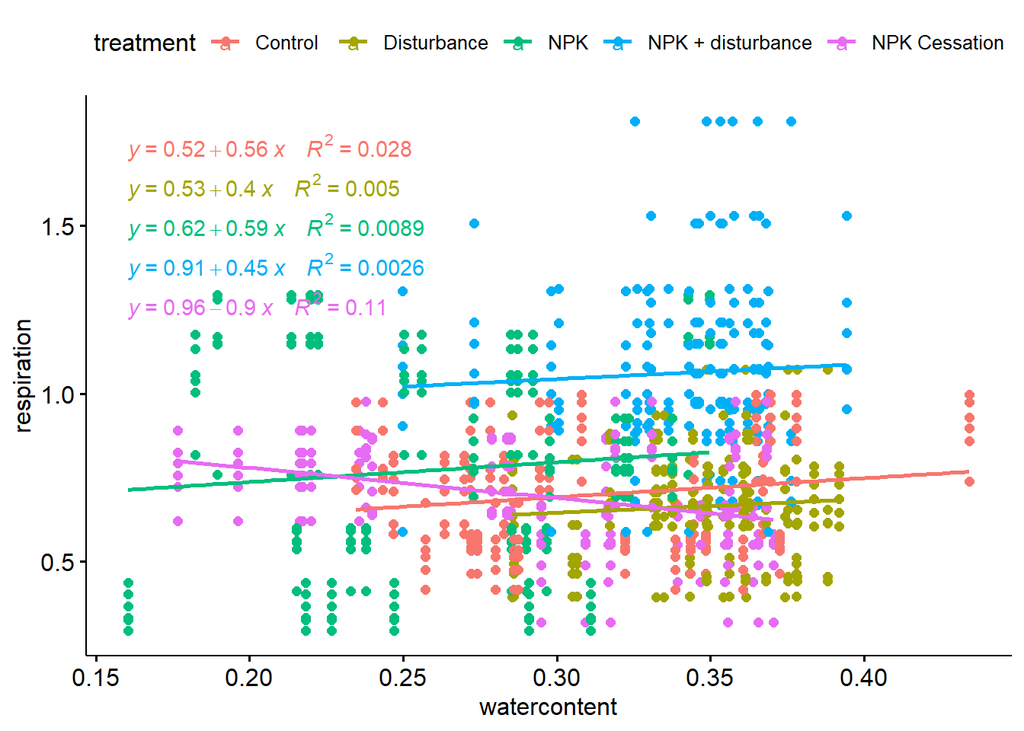

```r
data_w %>%
   pivot_longer(cols = starts_with("sw"),
               values_to = "watercontent",
               names_to = "x2"
               ) %>%
  mutate(x2 = gsub("water", "", x2)) %>%
  pivot_longer(cols = st1:st6,
               values_to = "soiltemp",
               names_to = "x3") %>%
  mutate(x3 = gsub("temp", "", x3)) %>%
  ggscatter(x= "watercontent", y ="respiration",
            color = "treatment", add = "reg.line")+
  stat_regline_equation(
    aes(label =  paste(..eq.label.., ..rr.label.., sep = "~~~~"), color = treatment)
    )
```

The linearity assumption seems to be not satisfied, and thus we move ahead with just the anova analysis.

### 5.5.1 default model

Here, we will setup the environment for model fitting and fit the default linear mixed-effects model.

```r
options(contrasts = c("contr.sum", "contr.poly"))

mix_mod <- lme(respiration ~ treatment*fdar,
                random = ~ 1 |rep/plot,
                data = data_w)
mix_mod
```

```
Linear mixed-effects model fit by REML
  Data: data_w
  Log-restricted-likelihood: 4.62517
  Fixed: respiration ~ treatment * fdar
     (Intercept)       treatment1       treatment2       treatment3
     0.779072533     -0.079573311     -0.113033200     -0.002695089
      treatment4            fdar1            fdar2            fdar3
     0.283915689      0.134168933      0.014826800      0.023681600
           fdar4            fdar5 treatment1:fdar1 treatment2:fdar1
    -0.076330000     -0.022053733     -0.079867489     -0.015200933
treatment3:fdar1 treatment4:fdar1 treatment1:fdar2 treatment2:fdar2
    -0.094987044      0.235365511     -0.052177355      0.067861867
treatment3:fdar2 treatment4:fdar2 treatment1:fdar3 treatment2:fdar3
     0.026331089     -0.013447689      0.024425178     -0.018804933
treatment3:fdar3 treatment4:fdar3 treatment1:fdar4 treatment2:fdar4
     0.057304956     -0.093456489      0.028861444     -0.059056000
treatment3:fdar4 treatment4:fdar4 treatment1:fdar5 treatment2:fdar5
    -0.002124111     -0.035777555      0.032505178     -0.032189600
treatment3:fdar5 treatment4:fdar5
     0.041106289     -0.060162489

Random effects:
 Formula: ~1 | rep
        (Intercept)
StdDev:  0.08661566

 Formula: ~1 | plot %in% rep
        (Intercept) Residual
StdDev:    0.151432 0.134204

Number of Observations: 150
Number of Groups:
          rep plot %in% rep
            5            25
```

In the following two chunks, we will gain further insights into the fitted linear mixed-effects model, including assessing the significance of fixed effects through ANOVA and examining the autocorrelation structure of the residuals.

```r
Anova(mix_mod,type = 3)
```

```
Analysis of Deviance Table (Type III tests)

Response: respiration
                 Chisq Df Pr(>Chisq)
(Intercept)    239.166  1  < 2.2e-16 ***
treatment       20.741  4  0.0003564 ***
fdar            42.494  5  4.678e-08 ***
treatment:fdar  34.186 20  0.0248959 *
---
Signif. codes:  0 '***' 0.001 '**' 0.01 '*' 0.05 '.' 0.1 ' ' 1
```

```r
ACF(mix_mod, resType = "n") %>%
  plot(alpha = 0.01)
```

[output not shown]

### 5.5.2 autroregressive moving average(ARMA)

In this chunk I will fit linear mixed-effects model with an autoregreessive moving average (ARMA) correlation structure to the data and assesses the autocorrelation structure of the residuals.

```r
mod2_ma <- lme(respiration ~ treatment*fdar,
                random = ~1 |rep/plot,
               correlation = corARMA(p = 1, q = 1),
                data = data_w)
mod2_ma
```

```
Linear mixed-effects model fit by REML
  Data: data_w
  Log-restricted-likelihood: 7.735458
  Fixed: respiration ~ treatment * fdar
     (Intercept)       treatment1       treatment2       treatment3
     0.779072533     -0.079573311     -0.113033200     -0.002695089
      treatment4            fdar1            fdar2            fdar3
     0.283915689      0.134168933      0.014826800      0.023681600
           fdar4            fdar5 treatment1:fdar1 treatment2:fdar1
    -0.076330000     -0.022053733     -0.079867489     -0.015200933
treatment3:fdar1 treatment4:fdar1 treatment1:fdar2 treatment2:fdar2
    -0.094987044      0.235365511     -0.052177355      0.067861867
treatment3:fdar2 treatment4:fdar2 treatment1:fdar3 treatment2:fdar3
     0.026331089     -0.013447689      0.024425178     -0.018804933
treatment3:fdar3 treatment4:fdar3 treatment1:fdar4 treatment2:fdar4
     0.057304956     -0.093456489      0.028861444     -0.059056000
treatment3:fdar4 treatment4:fdar4 treatment1:fdar5 treatment2:fdar5
    -0.002124111     -0.035777555      0.032505178     -0.032189600
treatment3:fdar5 treatment4:fdar5
     0.041106289     -0.060162489

Random effects:
 Formula: ~1 | rep
        (Intercept)
StdDev:  0.08733083

 Formula: ~1 | plot %in% rep
        (Intercept)  Residual
StdDev:   0.1561961 0.1279741

Correlation Structure: ARMA(1,1)
 Formula: ~1 | rep/plot
 Parameter estimate(s):
        Phi1       Theta1
-0.004900246 -0.442945994
Number of Observations: 150
Number of Groups:
          rep plot %in% rep
            5            25
```

The output of the model fitted with ARMA correlation structure looks okay

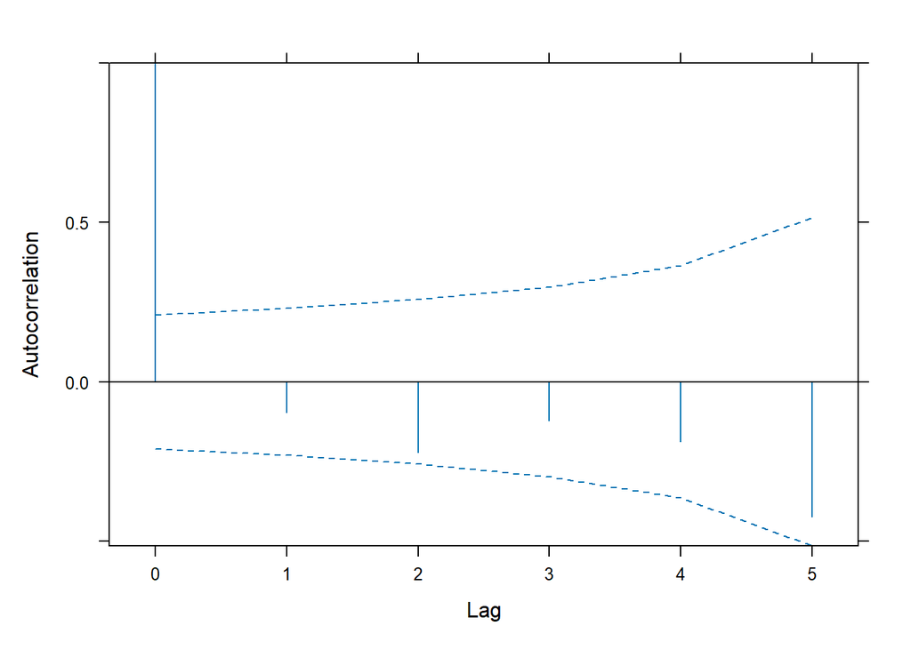

```r
ACF(mod2_ma,resType = "n") %>%
  plot(alpha = 0.01)
```

The ACF plot looks good, all the lags are within the threshold. Now, we compare this model with the default one

```r
anova(mix_mod,mod2_ma)
```

```
        Model df      AIC      BIC   logLik   Test  L.Ratio p-value
mix_mod     1 33 56.74966 148.7369 4.625170
mod2_ma     2 35 54.52908 152.0913 7.735458 1 vs 2 6.220576  0.0446
```

The AIC value for model 2 is lower than the default, which is a positive thing. But, BIC values do not represent the same. But, we will move on, and try to apply different correlation structures to see their effectiveness.

### 5.5.3 exponential correlation structure

In this chunk, I will fit the linear mixed model to the data, incorporating an exponential correlation structure to account for the correlation between observations based on the different level of days after rain.

```r
mod3_exp <- lme(respiration ~ treatment*fdar,
                random = ~1 |rep/plot,
                correlation = corExp(form = ~dar),
                data = data_w)
mod3_exp
```

```
Linear mixed-effects model fit by REML
  Data: data_w
  Log-restricted-likelihood: 4.62517
  Fixed: respiration ~ treatment * fdar
     (Intercept)       treatment1       treatment2       treatment3
     0.779072533     -0.079573311     -0.113033200     -0.002695089
      treatment4            fdar1            fdar2            fdar3
     0.283915689      0.134168933      0.014826800      0.023681600
           fdar4            fdar5 treatment1:fdar1 treatment2:fdar1
    -0.076330000     -0.022053733     -0.079867489     -0.015200933
treatment3:fdar1 treatment4:fdar1 treatment1:fdar2 treatment2:fdar2
    -0.094987044      0.235365511     -0.052177355      0.067861867
treatment3:fdar2 treatment4:fdar2 treatment1:fdar3 treatment2:fdar3
     0.026331089     -0.013447689      0.024425178     -0.018804933
treatment3:fdar3 treatment4:fdar3 treatment1:fdar4 treatment2:fdar4
     0.057304956     -0.093456489      0.028861444     -0.059056000
treatment3:fdar4 treatment4:fdar4 treatment1:fdar5 treatment2:fdar5
    -0.002124111     -0.035777555      0.032505178     -0.032189600
treatment3:fdar5 treatment4:fdar5
     0.041106289     -0.060162489

Random effects:
 Formula: ~1 | rep
        (Intercept)
StdDev:   0.0866165

 Formula: ~1 | plot %in% rep
        (Intercept)  Residual
StdDev:   0.1514323 0.1342039

Correlation Structure: Exponential spatial correlation
 Formula: ~dar | rep/plot
 Parameter estimate(s):
     range
0.04714572
Number of Observations: 150
Number of Groups:
          rep plot %in% rep
            5            25
```

```r
ACF(mod3_exp, resType = "n") %>%
  plot(alpha = 0.01)
```

[output not shown]

```r
anova(mix_mod,mod2_ma,mod3_exp)
```

```
         Model df      AIC      BIC   logLik   Test  L.Ratio p-value
mix_mod      1 33 56.74966 148.7369 4.625170
mod2_ma      2 35 54.52908 152.0913 7.735458 1 vs 2 6.220576  0.0446
mod3_exp     3 34 58.74966 153.5244 4.625170 2 vs 3 6.220576  0.0126
```

### 5.5.4 Gaussian

Here, we will fit the linear mixed model to the data, incorporating a Gaussian correlation structure and assess the autocorrelation structure of the residuals.

```r
mod4_gaus <- lme(respiration ~ treatment*fdar,
                random = ~1 |rep/plot,
                correlation = corGaus(form = ~dar),
                data = data_w)
mod4_gaus
```

```
Linear mixed-effects model fit by REML
  Data: data_w
  Log-restricted-likelihood: 4.62517
  Fixed: respiration ~ treatment * fdar
     (Intercept)       treatment1       treatment2       treatment3
     0.779072533     -0.079573311     -0.113033200     -0.002695089
      treatment4            fdar1            fdar2            fdar3
     0.283915689      0.134168933      0.014826800      0.023681600
           fdar4            fdar5 treatment1:fdar1 treatment2:fdar1
    -0.076330000     -0.022053733     -0.079867489     -0.015200933
treatment3:fdar1 treatment4:fdar1 treatment1:fdar2 treatment2:fdar2
    -0.094987044      0.235365511     -0.052177355      0.067861867
treatment3:fdar2 treatment4:fdar2 treatment1:fdar3 treatment2:fdar3
     0.026331089     -0.013447689      0.024425178     -0.018804933
treatment3:fdar3 treatment4:fdar3 treatment1:fdar4 treatment2:fdar4
     0.057304956     -0.093456489      0.028861444     -0.059056000
treatment3:fdar4 treatment4:fdar4 treatment1:fdar5 treatment2:fdar5
    -0.002124111     -0.035777555      0.032505178     -0.032189600
treatment3:fdar5 treatment4:fdar5
     0.041106289     -0.060162489

Random effects:
 Formula: ~1 | rep
        (Intercept)
StdDev:   0.0866165

 Formula: ~1 | plot %in% rep
        (Intercept)  Residual
StdDev:   0.1514323 0.1342039

Correlation Structure: Gaussian spatial correlation
 Formula: ~dar | rep/plot
 Parameter estimate(s):
    range
0.2192792
Number of Observations: 150
Number of Groups:
          rep plot %in% rep
            5            25
```

```r
ACF(mod4_gaus, resType = "n") %>%
  plot(alpha = 0.01)
```

[output not shown]

```r
anova(mix_mod,mod2_ma,mod3_exp, mod4_gaus)
```

```
          Model df      AIC      BIC   logLik   Test  L.Ratio p-value
mix_mod       1 33 56.74966 148.7369 4.625170
mod2_ma       2 35 54.52908 152.0913 7.735458 1 vs 2 6.220576  0.0446
mod3_exp      3 34 58.74966 153.5244 4.625170 2 vs 3 6.220576  0.0126
mod4_gaus     4 34 58.74966 153.5244 4.625170
```

Still model 2 with ARMA is the best performing.

### 5.5.5 Linear

Here, we will fit the linear mixed model to the data, incorporating a Linear correlation structure and assess the autocorrelation structure of the residuals.

```r
mod5_lin <- lme(respiration ~ treatment*fdar,
                random = ~1 |rep/plot,
                correlation = corLin(form = ~dar),
                data = data_w)

mod5_lin
```

```
Linear mixed-effects model fit by REML
  Data: data_w
  Log-restricted-likelihood: 4.62517
  Fixed: respiration ~ treatment * fdar
     (Intercept)       treatment1       treatment2       treatment3
     0.779072533     -0.079573311     -0.113033200     -0.002695089
      treatment4            fdar1            fdar2            fdar3
     0.283915689      0.134168933      0.014826800      0.023681600
           fdar4            fdar5 treatment1:fdar1 treatment2:fdar1
    -0.076330000     -0.022053733     -0.079867489     -0.015200933
treatment3:fdar1 treatment4:fdar1 treatment1:fdar2 treatment2:fdar2
    -0.094987044      0.235365511     -0.052177355      0.067861867
treatment3:fdar2 treatment4:fdar2 treatment1:fdar3 treatment2:fdar3
     0.026331089     -0.013447689      0.024425178     -0.018804933
treatment3:fdar3 treatment4:fdar3 treatment1:fdar4 treatment2:fdar4
     0.057304956     -0.093456489      0.028861444     -0.059056000
treatment3:fdar4 treatment4:fdar4 treatment1:fdar5 treatment2:fdar5
    -0.002124111     -0.035777555      0.032505178     -0.032189600
treatment3:fdar5 treatment4:fdar5
     0.041106289     -0.060162489

Random effects:
 Formula: ~1 | rep
        (Intercept)
StdDev:   0.0866165

 Formula: ~1 | plot %in% rep
        (Intercept)  Residual
StdDev:   0.1514323 0.1342039

Correlation Structure: Linear spatial correlation
 Formula: ~dar | rep/plot
 Parameter estimate(s):
range
    1
Number of Observations: 150
Number of Groups:
          rep plot %in% rep
            5            25
```

```r
ACF(mod5_lin, resType = "n") %>%
  plot(alpha = 0.01)
```

[output not shown]

```r
anova(mix_mod,mod2_ma,mod3_exp, mod4_gaus,mod5_lin)
```

```
          Model df      AIC      BIC   logLik   Test  L.Ratio p-value
mix_mod       1 33 56.74966 148.7369 4.625170
mod2_ma       2 35 54.52908 152.0913 7.735458 1 vs 2 6.220576  0.0446
mod3_exp      3 34 58.74966 153.5244 4.625170 2 vs 3 6.220576  0.0126
mod4_gaus     4 34 58.74966 153.5244 4.625170
mod5_lin      5 34 58.74966 153.5244 4.625170
```

### 5.5.6 Rational quadratic

We will fit the linear mixed model to the data, incorporating a Rational Quadratic correlation structure and assess the autocorrelation structure of the residuals.

```r
mod6_rq <- lme(respiration ~ treatment*fdar,
                random = ~1 |rep/plot,
                correlation = corRatio(form = ~dar),
                data = data_w)
mod6_rq
```

```
Linear mixed-effects model fit by REML
  Data: data_w
  Log-restricted-likelihood: 4.62517
  Fixed: respiration ~ treatment * fdar
     (Intercept)       treatment1       treatment2       treatment3
     0.779072533     -0.079573311     -0.113033200     -0.002695089
      treatment4            fdar1            fdar2            fdar3
     0.283915689      0.134168933      0.014826800      0.023681600
           fdar4            fdar5 treatment1:fdar1 treatment2:fdar1
    -0.076330000     -0.022053733     -0.079867489     -0.015200933
treatment3:fdar1 treatment4:fdar1 treatment1:fdar2 treatment2:fdar2
    -0.094987044      0.235365511     -0.052177355      0.067861867
treatment3:fdar2 treatment4:fdar2 treatment1:fdar3 treatment2:fdar3
     0.026331089     -0.013447689      0.024425178     -0.018804933
treatment3:fdar3 treatment4:fdar3 treatment1:fdar4 treatment2:fdar4
     0.057304956     -0.093456489      0.028861444     -0.059056000
treatment3:fdar4 treatment4:fdar4 treatment1:fdar5 treatment2:fdar5
    -0.002124111     -0.035777555      0.032505178     -0.032189600
treatment3:fdar5 treatment4:fdar5
     0.041106289     -0.060162489

Random effects:
 Formula: ~1 | rep
        (Intercept)
StdDev:   0.0866165

 Formula: ~1 | plot %in% rep
        (Intercept)  Residual
StdDev:   0.1514323 0.1342039

Correlation Structure: Rational quadratic spatial correlation
 Formula: ~dar | rep/plot
 Parameter estimate(s):
       range
3.406585e-05
Number of Observations: 150
Number of Groups:
          rep plot %in% rep
            5            25
```

```r
ACF(mod6_rq, resType = "n") %>%
  plot(alpha = 0.01)
```

[output not shown]

```r
anova(mix_mod,mod2_ma,mod3_exp, mod4_gaus,mod5_lin,mod6_rq)
```

```
          Model df      AIC      BIC   logLik   Test  L.Ratio p-value
mix_mod       1 33 56.74966 148.7369 4.625170
mod2_ma       2 35 54.52908 152.0913 7.735458 1 vs 2 6.220576  0.0446
mod3_exp      3 34 58.74966 153.5244 4.625170 2 vs 3 6.220576  0.0126
mod4_gaus     4 34 58.74966 153.5244 4.625170
mod5_lin      5 34 58.74966 153.5244 4.625170
mod6_rq       6 34 58.74966 153.5244 4.625170
```

### 5.5.7 Spherical

We will fit the linear mixed model to the data, incorporating a Spherical correlation structure and assess the autocorrelation structure of the residuals.

```r
mod7_sph <- lme(respiration ~ treatment*fdar,
                random = ~1 |rep/plot,
                correlation = corSpher(form = ~dar),
                data = data_w)
mod7_sph
```

```
Linear mixed-effects model fit by REML
  Data: data_w
  Log-restricted-likelihood: 4.62517
  Fixed: respiration ~ treatment * fdar
     (Intercept)       treatment1       treatment2       treatment3
     0.779072533     -0.079573311     -0.113033200     -0.002695089
      treatment4            fdar1            fdar2            fdar3
     0.283915689      0.134168933      0.014826800      0.023681600
           fdar4            fdar5 treatment1:fdar1 treatment2:fdar1
    -0.076330000     -0.022053733     -0.079867489     -0.015200933
treatment3:fdar1 treatment4:fdar1 treatment1:fdar2 treatment2:fdar2
    -0.094987044      0.235365511     -0.052177355      0.067861867
treatment3:fdar2 treatment4:fdar2 treatment1:fdar3 treatment2:fdar3
     0.026331089     -0.013447689      0.024425178     -0.018804933
treatment3:fdar3 treatment4:fdar3 treatment1:fdar4 treatment2:fdar4
     0.057304956     -0.093456489      0.028861444     -0.059056000
treatment3:fdar4 treatment4:fdar4 treatment1:fdar5 treatment2:fdar5
    -0.002124111     -0.035777555      0.032505178     -0.032189600
treatment3:fdar5 treatment4:fdar5
     0.041106289     -0.060162489

Random effects:
 Formula: ~1 | rep
        (Intercept)
StdDev:   0.0866165

 Formula: ~1 | plot %in% rep
        (Intercept)  Residual
StdDev:   0.1514323 0.1342039

Correlation Structure: Spherical spatial correlation
 Formula: ~dar | rep/plot
 Parameter estimate(s):
   range
1.000022
Number of Observations: 150
Number of Groups:
          rep plot %in% rep
            5            25
```

```r
ACF(mod7_sph, resType = "n") %>%
  plot(alpha = 0.01)
```

[output not shown]

## 5.6 Final comparison

Here, we will run a ANOVA based on different model, allowing for the comparison of the models based on their AIC values.

```r
anova(mix_mod, mod2_ma, mod3_exp, mod4_gaus, mod5_lin, mod6_rq, mod7_sph) %>%
  as.data.frame() %>%
  rownames_to_column(var = "modelname") %>%
  janitor::clean_names() %>%
  dplyr::select(modelname, model, df, aic, bic) %>%
  arrange(aic)
```

```
  modelname model df      aic      bic
1   mod2_ma     2 35 54.52908 152.0913
2   mix_mod     1 33 56.74966 148.7369
3  mod3_exp     3 34 58.74966 153.5244
4  mod7_sph     7 34 58.74966 153.5244
5  mod5_lin     5 34 58.74966 153.5244
6 mod4_gaus     4 34 58.74966 153.5244
7   mod6_rq     6 34 58.74966 153.5244
```

From the above table, we were able to say that Auturegressive Moving Average (ARMA) performed the best, since it had the lowest AIC values. We will base our analysis on the same.

## 5.7 Residual extraction

Here, we will extract the model residuals and calculate standardized residuals and keep in tidy format.

```r
library(broom.mixed)
mod2_ma_resid <- augment(mod2_ma) %>%
  mutate(.stdresid = resid(mod2_ma,
                           type = "pearson",
                           scaled = T
                           ))
mod2_ma_resid
```

```
# A tibble: 150 × 23
   plot  treatment    swc1  swc2  swc3  swc4  swc5  swc6   st1   st2   st3   st4
   <fct> <fct>       <dbl> <dbl> <dbl> <dbl> <dbl> <dbl> <dbl> <dbl> <dbl> <dbl>
 1 1     Disturbance 0.343 0.356 0.306 0.378 0.286 0.305  15.1  18.4  19.2  12.1
 2 1     Disturbance 0.343 0.356 0.306 0.378 0.286 0.305  15.1  18.4  19.2  12.1
 3 1     Disturbance 0.343 0.356 0.306 0.378 0.286 0.305  15.1  18.4  19.2  12.1
 4 1     Disturbance 0.343 0.356 0.306 0.378 0.286 0.305  15.1  18.4  19.2  12.1
 5 1     Disturbance 0.343 0.356 0.306 0.378 0.286 0.305  15.1  18.4  19.2  12.1
 6 1     Disturbance 0.343 0.356 0.306 0.378 0.286 0.305  15.1  18.4  19.2  12.1
 7 2     NPK Cessat… 0.317 0.356 0.365 0.309 0.370 0.295  17.0  19.0  18.7  11.9
 8 2     NPK Cessat… 0.317 0.356 0.365 0.309 0.370 0.295  17.0  19.0  18.7  11.9
 9 2     NPK Cessat… 0.317 0.356 0.365 0.309 0.370 0.295  17.0  19.0  18.7  11.9
10 2     NPK Cessat… 0.317 0.356 0.365 0.309 0.370 0.295  17.0  19.0  18.7  11.9
# ℹ 140 more rows
# ℹ 11 more variables: st5 <dbl>, st6 <dbl>, rep <fct>, respiration <dbl>,
#   date <date>, dar <dbl>, fdar <fct>, .fitted <dbl>, .resid <dbl>,
#   .fixed <dbl>, .stdresid <dbl>
```

## 5.8 Block random effect

Here, random effects from the linear mixed model (mod2_ma) will be extracted and visualized using Quantitle-quantile(QQ) plot to assess the normality of the random effect.

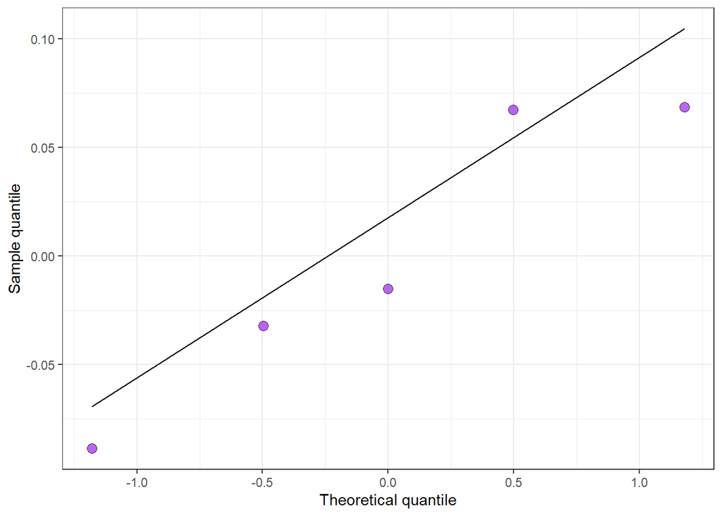

```r
ranef(mod2_ma)[[1]] %>%
   ggplot(aes(sample=`(Intercept)`))+
  stat_qq(  shape = 21,
            fill = "purple",
            size = 3,
            alpha = .7
  )+
  stat_qq_line()+
  labs(x = "Theoretical quantile",
       y = "Sample quantile")+
  theme_bw()
```

The points seem a little off, but nothing too worrying.

## 5.9 blocks:plots random effects

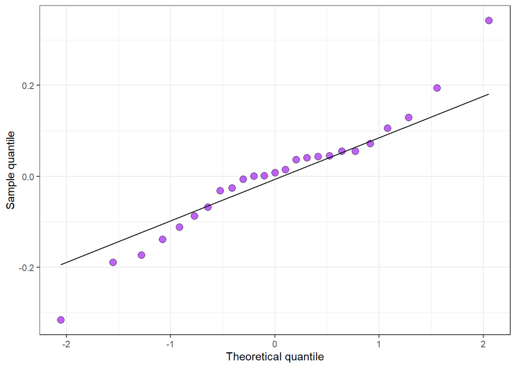

```r
ranef(mod2_ma)[[2]] %>%
   ggplot(aes(sample=`(Intercept)`))+
  stat_qq(  shape = 21,
            fill = "purple",
            size = 3,
            alpha = .7
  )+
  stat_qq_line()+
  labs(x = "Theoretical quantile",
       y = "Sample quantile")+
  theme_bw()
```

The tails are a little off, but this is to be expected in limited number of data points.

## 5.10 within groups errors

Here we will run a diagnostic plot to assess the goodness-of-fit of the linear mixed effects model, examining the standardized residuals against fitted values to identify potential outliers and assess the trend in the residuals.

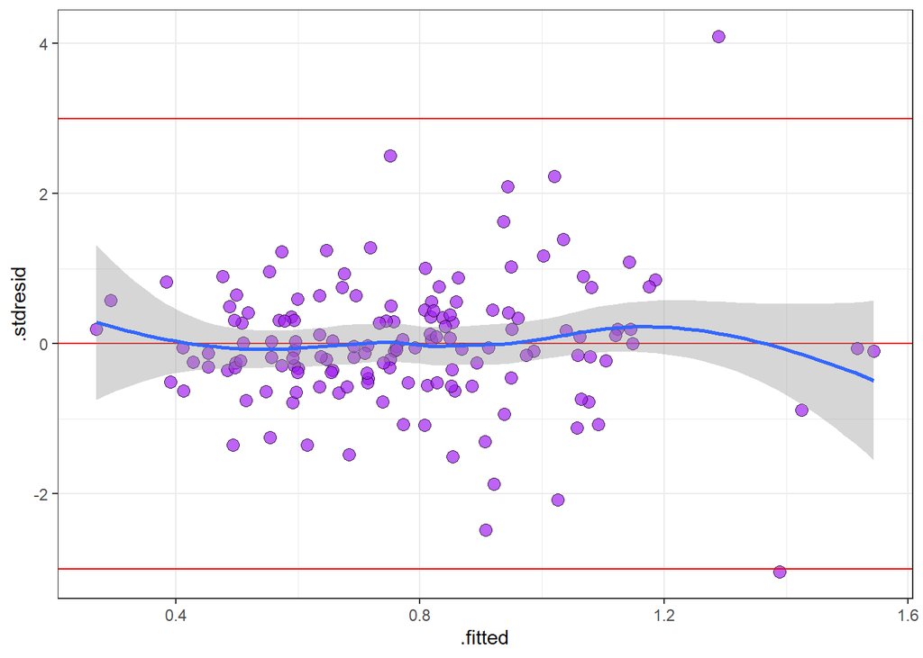

```r
ggplot(mod2_ma_resid, aes(x=.fitted, y=.stdresid))+
  geom_hline(yintercept = 0, color="red")+
  geom_point(shape = 21,
             fill = "purple",
             size = 3,
             alpha = .7)+
  geom_smooth()+
  geom_hline(yintercept = c(-3,3), color = "red")+
  theme_bw()
```

We do see that thre are two residual outliers, but upon further examination of our raw data we decided to leave the outliers as is. The raw data points did not seem too much out of the ordinary, and hence we had to make a personal choice of retaining the outlier, even though it might skew our analysis a bit.

## 5.11 Normality assumption of residuals

Here, we will run QQ plot to visualize whether the standardized residuals follow normal distribution.

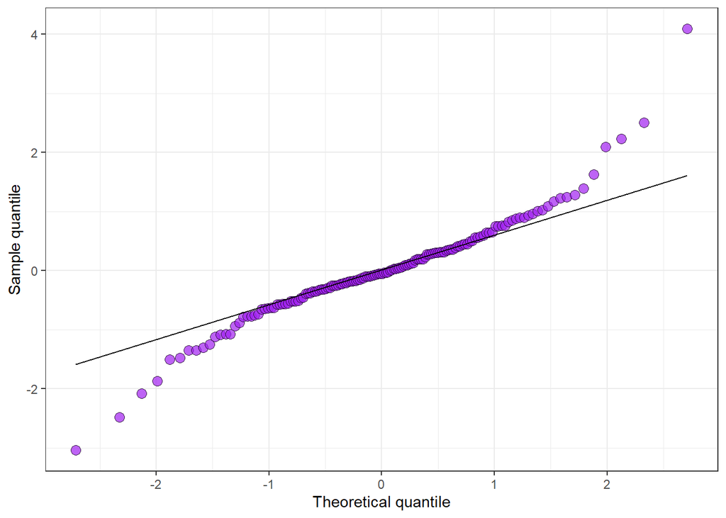

```r
ggplot(mod2_ma_resid, aes(sample=.stdresid))+
  stat_qq(  shape = 21,
            fill = "purple",
            size = 3,
            alpha = .7
  )+
  stat_qq_line()+
  labs(x = "Theoretical quantile",
       y = "Sample quantile")+
  theme_bw()
```

Although the tails are a bit off, it does not seem to be a problem.

Here, we will run type III ANOVA table for the fixed effects in mod2_ma and observe the significant factor.

```r
Anova(mod2_ma, type = 3)
```

```
Analysis of Deviance Table (Type III tests)

Response: respiration
                 Chisq Df Pr(>Chisq)
(Intercept)    238.710  1  < 2.2e-16 ***
treatment       21.149  4  0.0002958 ***
fdar            64.949  5  1.148e-12 ***
treatment:fdar  45.311 20  0.0010013 **
---
Signif. codes:  0 '***' 0.001 '**' 0.01 '*' 0.05 '.' 0.1 ' ' 1
```

We see a significant interaction effects, and hence we go ahead with the comparison of means of all treatments crossed with the days after rain.

## 5.12 treatment x fdar Interaction

Here, we compare means between different treatments within each day of measurement.

```r
rm_rcbd_cld_tfdar <- emmeans(mod2_ma, ~ treatment|fdar) %>%
  cld(reversed = T,
      Letters = letters,
      adjust = "none") %>%
  as.data.frame() %>%
  mutate(letter = trimws(.group))

  head(rm_rcbd_cld_tfdar)
```

```
          treatment fdar    emmean         SE df  lower.CL upper.CL .group
1 NPK + disturbance   01 1.4325227 0.09838829  4 1.1593530 1.705692     a
5               NPK   01 0.8155593 0.09838829  4 0.5423897 1.088729      b
2       Disturbance   01 0.7850073 0.09838829  4 0.5118377 1.058177      b
3     NPK Cessation   01 0.7793173 0.09838829  4 0.5061477 1.052487      b
4          Control    01 0.7538007 0.09838829  4 0.4806310 1.026970      b
6 NPK + disturbance   02 1.0643673 0.09838829  4 0.7911977 1.337537     a
  letter
1      a
5      b
2      b
3      b
4      b
6      a
```

## 5.13 Final plot 1 (treatment in dar)

In this chunk, we will see the effects of different treatments on each of the different days. Different letters signify difference.

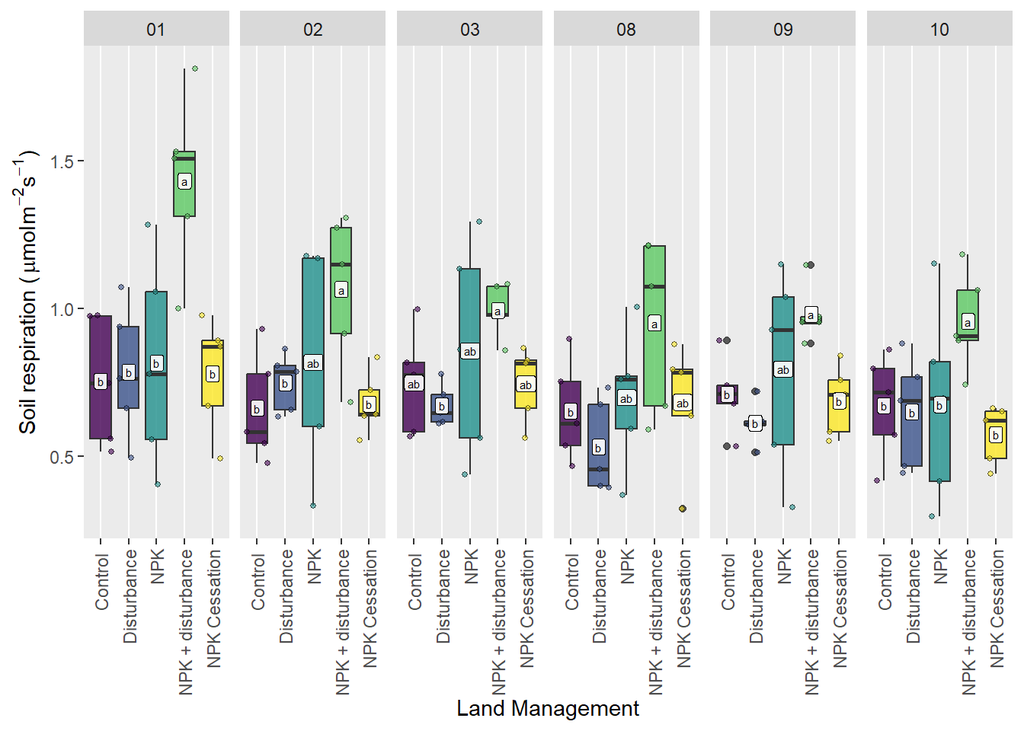

```r
ggplot(mapping = aes(fill = treatment))+
  geom_boxplot(data = data_w,
               aes(x =treatment,
                   y = respiration),
               alpha = 0.8) +
  geom_jitter(data = data_w,
              aes(x= treatment,
                  y = respiration),
              shape = 21,
              size = 1,
              alpha = 0.6) +
  geom_label(data = rm_rcbd_cld_tfdar,
             aes(x= treatment,
                 y = emmean,
                 label = letter),
             fill = "white",
             size = 2,
             alpha = 0.9) +
 labs(x = "Land Management",
       y = bquote("Soil respiration ("*mu* "mol" * "m" ^-2 * "s"^-1 *")"))+
  scale_fill_viridis_d() +
  facet_grid(.~fdar) +
  theme(panel.grid.major.y = element_blank(),
        panel.grid.minor.y = element_blank(),
        legend.position = "none",
        axis.text.x = element_text(angle = 90,
                                   vjust = 0.5,
                                   hjust = 1))
```

Overall, on all days soil efflux values from NPK + disturbance plots were higher than the other treatment plots, especially on day 1 and day 10 after rain, where we see a statistically significant difference between the combined treatment and the other treatments. It is also interesting to note the variability in efflux values in NPK plots.

In the chunk below, we compare means of different days after rain within each treatment plots.

```r
rm_rcbd_cld_dartf <- emmeans(mod2_ma, ~ fdar|treatment) %>%
  cld(reversed = T,
      Letters = letters,
      adjust = "none") %>%
  as.data.frame() %>%
  mutate(letter = trimws(.group))
head(rm_rcbd_cld_dartf)
```

```
  fdar treatment    emmean         SE df  lower.CL  upper.CL .group letter
4   01  Control  0.7538007 0.09838829  4 0.4806310 1.0269703      a      a
2   03  Control  0.7476060 0.09838829  4 0.4744363 1.0207757      a      a
6   09  Control  0.7099507 0.09838829  4 0.4367810 0.9831203      a      a
5   10  Control  0.6714587 0.09838829  4 0.3982890 0.9446283      a      a
3   02  Control  0.6621487 0.09838829  4 0.3889790 0.9353183      a      a
1   08  Control  0.6520307 0.09838829  4 0.3788610 0.9252003      a      a
```

## 5.14 Final plot 2 (dar in treatment)

In this chunk, we see how soil respiration varies across different levels of the drying cycle(“fdar”) highlighting significant difference between levels within treatment groups will be visualized using boxplot.

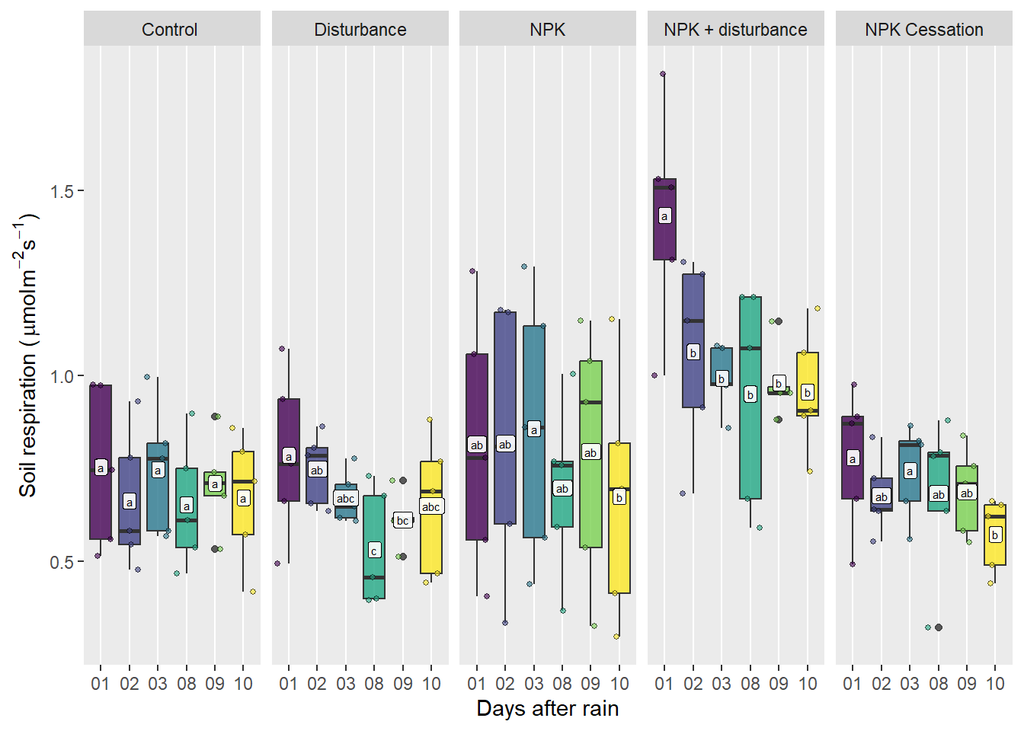

```r
ggplot(mapping = aes(fill = fdar))+
  geom_boxplot(data = data_w,
               aes(x =fdar,
                   y = respiration),
               alpha = 0.8) +
  geom_jitter(data = data_w,
              aes(x= fdar,
                  y = respiration),
              shape = 21,
              size = 1,
              alpha = 0.6) +
  geom_label(data = rm_rcbd_cld_dartf,
             aes(x= fdar,
                 y = emmean,
                 label = letter),
             fill = "white",
             size = 2,
             alpha = 0.9) +
 labs(x = "Days after rain",
       y = bquote("Soil respiration ("*mu* "mol" * "m" ^-2 * "s"^-1 *")"))+
  scale_fill_viridis_d() +
  facet_grid(.~treatment) +
  theme(panel.grid.major.y = element_blank(),
        panel.grid.minor.y = element_blank(),
        legend.position = "none")
```

From the above graph, we can say that soil respiration spikes a day after rain in plots treated with NPK + disturbance. This confirms our hypothesis that soils with combined treatments of NPK + disturbance will have a higher CO2 efflux following a rain event.

# 6 Team work in GitHub

# 7 Submitting your work

Once you have developed all the code and answers, make sure to Render this quarto file.

Rename this file to `LASTNAME1-LASTNAME2_midtermproject.html`.  
For ex., `Bastos-Mendes_midtermproject.html`.

Send the html file to my email (lmbastos@uga.edu) by **April 11th** 11:59 pm.

# 8 References

1.Bond-Lamberty, B. and Thomson, A. (2010). Temperature-associated increases in the global soil respiration record. Nature, 464(7288):579–582.

2.Ding, W., Yu, H., Cai, Z., Han, F., & Xu, Z. (2010). Responses of soil respiration to N fertilization in a loamy soil under maize cultivation. Geoderma, 155(3-4), 381-389.

3.Fiedler, S. R., Buczko, U., Jurasinski, G., & Glatzel, S. (2015). Soil respiration after tillage under different fertiliser treatments–implications for modelling and balancing. Soil and Tillage Research, 150, 30-42.

4.Morell, F. J., Whitmore, A. P., Álvaro-Fuentes, J., Lampurlanés, J., & Cantero-Martínez, C. (2012). Root respiration of barley in a semiarid Mediterranean agroecosystem: field and modelling approaches. Plant and soil, 351, 135-147.

5.Muhr, J., & Borken, W. (2009). Delayed recovery of soil respiration after wetting of dry soil further reduces C losses from a Norway spruce forest soil. Journal of Geophysical Research: Biogeosciences , 114 (G4).

6.Leppink, J. (2018). Analysis of Covariance (ANCOVA) vs. Moderated Regression (MODREG): Why the Interaction Matters. Health Professions Education, 4(3), 225–232. https://doi.org/10.1016/j.hpe.2018.04.001.

7.Pinheiro J, Bates D, R Core Team (2023). nlme: Linear and Nonlinear Mixed Effects Models. R package version 3.1-164, https://CRAN.R-project.org/package=nlme.

8.Shi, W. Y., Tateno, R., Zhang, J. G., Wang, Y. L., Yamanaka, N., & Du, S. (2011). Response of soil respiration to precipitation during the dry season in two typical forest stands in the forest–grassland transition zone of the Loess Plateau. Agricultural and forest meteorology, 151(7), 854-863.

9.Wang, W., & Fang, J. (2009). Soil respiration and human effects on global grasslands. Global and Planetary Change , 67 (1-2), 20-28.